# LPCC02 - Lab 2 - Checkpoint 1

**Tiago Lucas Pereira Clementino**

**13 de abril de 2018**

### Bibliotecas utilizadas

```r
library(tidyverse)
library(here)
library(knitr)
library(gridExtra)
library(ggExtra)
library(gapminder)
library(ggalt)
theme_set(theme_bw())
options(warn=-1)
```

# Contexto

Nosso objetivo é analisar e extrair informação de dados coletados por uma plataforma aberta de integração contínua chamada Travistorrent. O Travisttorrent é um serviço de integração contínua de projetos disponíveis no Github, um repositório de projetos colaborativos também aberto.

A integração contínua é um processo onde o desenvolvedor integra o código alterado e/ou criado ao projeto principal na mesma frequência com que as funcionalidades são introduzidas.

Nossa intenção é analisar os dados fazendo um paralelo entre as linguagens de programação Java e Ruby, levantando questões inerentes às características dos projetos de software que as utilizam. Diante disto, descartamos quaisquer dados referentes a outras linguagens.

# Nossos Dados

Os dados são informações diversas referentes a projetos disponíveis no Github e que, no momento da coleta, utilizaram o Travistorent nos ultimos três meses e corresponderam a certas especificações de filtragem. Estas informações descrevem operações inerentes ao andamento de projetos no Github e a procedimentos de integração contínua (testes, *commits*, PR, *builds* de integração, etc) ao longo de um certo período de tempo.

### Carregando os dados

```r
projetos = read_csv(here::here("dados/projetos.csv"))
```

### Filtrando os dados (eliminando linguagens diferentes de Java e Ruby identificadas)

```r
projetos = projetos %>%
    filter(lang != "javascript")
```

# Variáveis

Nossa base de dados conta com variáveis bem intuitivas.

```r
projetos %>% names()
```

```
##  [1] "gh_project_name"       "team"
##  [3] "lang"                  "sloc_end"
##  [5] "sloc_med"              "activity_period"
##  [7] "num_commits"           "commits_per_month"
##  [9] "tests_per_kloc"        "total_builds"
## [11] "build_success_prop"    "builds_per_month"
## [13] "tests_added_per_build" "tests_successful"
## [15] "test_density"          "test_size_avg"
```

Cada uma delas descreve alguma característica dos projetos.

| Nome | Descrição | Tipo |
| --- | --- | --- |
| **gh_project_name** | nome do projeto | Categórica |
| **team** | total de desenvolvedores que participaram do projeto até sua última medição | Numérica |
| **lang** | linguagem de programação predominante | Categórica |
| **sloc_end** | total de linhas de código na última medição do projeto | Numérica |
| **sloc_med** | total de linhas de código no meio do tempo de atividade estimado do projeto | Numérica |
| **activity_period** | tempo de atividade estimado do projeto | Numérica |
| **num_commits** | total de submissões de alteração durante todo o tempo de atividade do projeto | Numérica |
| **commits_per_month** | total de submissões por mês | Numérica |
| **tests_per_kloc** | casos de teste por total de linhas de código | Numérica |
| **total_builds** | total de integrações | Numérica |
| **build_success_prop** | proporção de integrações bem-sucedidas | Numérica |
| **builds_per_month** | total médio de integrações por mês | Numérica |
| **tests_added_per_build** | total médio de testes adicionados por integração | Numérica |
| **tests_successful** | total de testes bem-sucedidos | Numérica |
| **test_density** | densidade de testes | Numérica |
| **test_size_avg** | tamanho médio dos casos de testes | Numérica |

Na nossa análise usaremos apenas as variáveis **sloc_end**, **team**, **activity_period**, **build_success_prop**, **test_size_avg**, **tests_per_kloc** e **lang**.

# Distribuições dos dados entre Java e Ruby

O gráfico abaixo apresenta a distribuição dos dados entre Java e Ruby. É fácil perceber que a vantagem numérica de Ruby em relação à Java é grande. Nossas análises farão um paralelo entre estas duas linguagens.

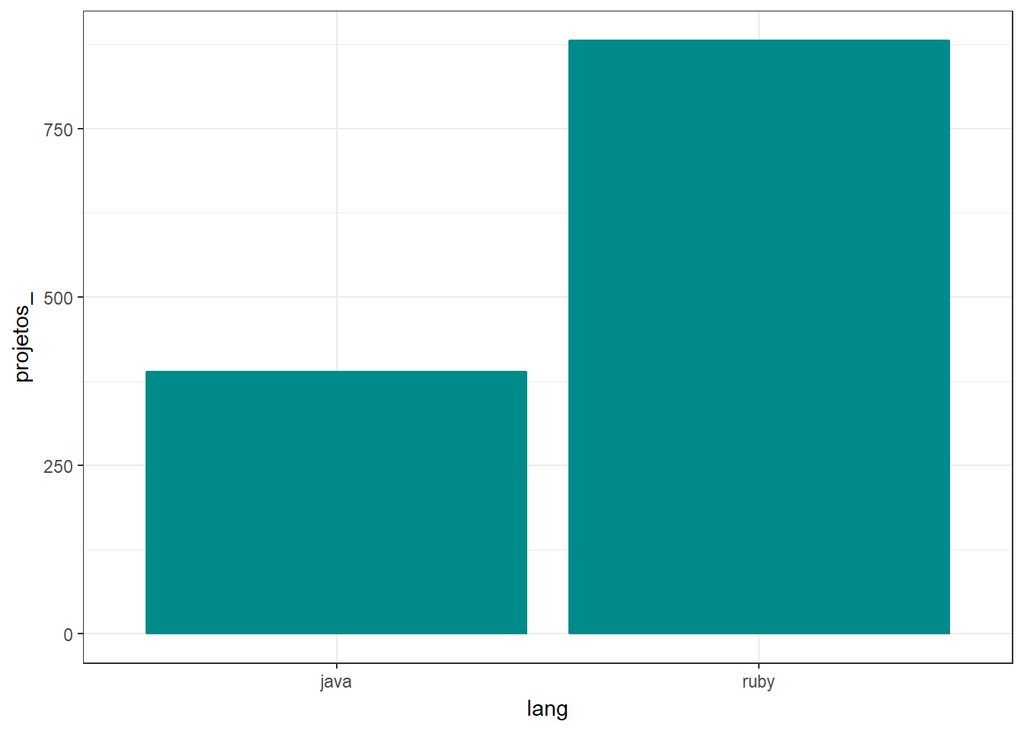

```r
projetos %>%
    group_by(lang) %>%
    summarise(projetos_ = n()) %>%
    ggplot(aes(x = lang, y = projetos_)) +
    geom_col(fill = "darkcyan", color = "darkcyan")
```

# Objetivos

Precisamos avaliar um conjunto de variáveis em um exercício de visualização de dados e correlações. O objetivo de nossa investigação é entender os dados e as relações entre suas variáveis. Tendo isto em vista, é importante ser capaz de escolher as marcas adequados para nossa análise.

Uma marca é elemento visual presente no gráfico que descreve uma variável, seja ela nominal, ordinal ou numérica. Como exemplos podemos usar diferentes cores para diferentes categorias, as dimensões em um plano para correlacionar duas variáveis, diferentes formas, gradientes e tamanhos de pontos em um gráfico de dispersão, etc.

A partir disto devemos propor questões questões arbitrárias que julguemos interessantes correlacionando variáveis, para em seguida proceder a análise.

### Regras

De acordo com o enunciado do Laboratório 2 da disciplina LPCC2, devemos elaborar pelo menos seis gráficos envolvendo quatro variáveis diferentes. Cada um com ao memos duas marcas direntes.

# Variáveis de estudo.

Selecionamos para este relatório quatro variáveis que serão alvo de comparações, medições e visualizações, são elas: **sloc_end**, **sloc_med**, **tests_per_kloc** e **test_size_avg**, outras variáveis também podem ser usadas na comparação, como **lang** ou **team**. Nosso objetivo é observar seu comportamento com base em confirmar ou refutar certas prespectivas de correlação que chamaremos de questões e são descritas abaixo.

# Análise

A partir daqui analisaremos nossos dados com base em questões levantadas a partir de correlações entre variáveis. Nosso primeiro objetivo é entender como o volume de código se comporta ao longo do tempo, e faremos isto comparando as variáveis **sloc_end** e **sloc_med** em relação à outras variáveis. Em seguida tentaremos enteder a relação entre **tests_per_kloc** e **test_size_avg**, sempre fazendo um paralelo com variáveis significativas como **lang** e/ou **team**.

### **sloc_end** e **sloc_med**

A principal relação entre estas duas variáveis é o tempo. **sloc_med**, como já foi mensionado, mede o volume de código de um projeto na metade de seu tempo de vida (até o fim da medição dos dados), já **sloc_end** mede o volume total de código no fim do período de medição. É de se esperar que **sloc_med** sejá melhor que **sloc_end**, mas qual a proporçõa desta diferença?

#### Gráfico de dispersão

Para começar a responder esta pergunta poderiamos pensar usar um gráfico de disperção (scattler plot), que descreve a posição de cada projeto em um plano cartesiano onde x é o **sloc_end** e y é **sloc_med**.

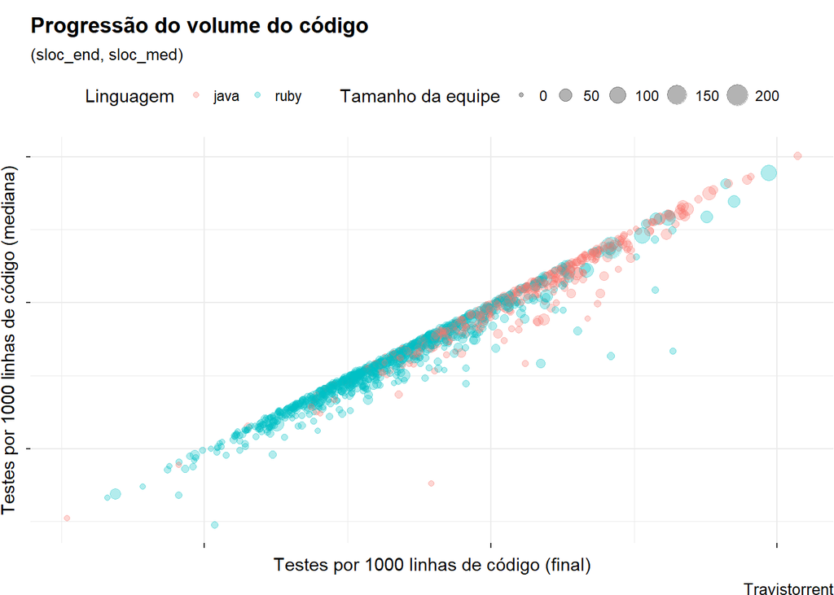

```r
projetos %>%
    ggplot(aes(x= sloc_end, y= sloc_med , color = lang, size=team),na.rm=TRUE) +
    scale_x_log10()+
    scale_y_log10()+
    geom_point(alpha = .3) +
        labs(x='Testes por 1000 linhas de código (final)',
             y='Testes por 1000 linhas de código (mediana)',
             title='Progressão do volume do código',
             color='Linguagem',
             size='Tamanho da equipe',
             subtitle='(sloc_end, sloc_med)',
             caption="Travistorrent") +
  theme_bw() +
  theme(plot.title = element_text(face="bold"),
        panel.border=element_blank(),
        legend.position="top",
        axis.text.x = element_blank(),
        axis.text.y = element_blank(),
        plot.margin=unit(c(10,0,0,0),"points"))
```

Dumbbell Plot - entre sloc_med e sloc_end

comparar com os valores de sloc_med e sloc_end-sloc_med (da uma relação de quase dois para um)

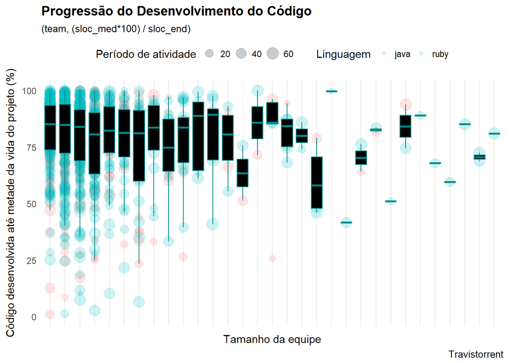

```r
projetos %>%
  ggplot(aes(x=cut(team, breaks=100), y=(sloc_med*100)/sloc_end)) +
  #geom_violin()
  geom_count(aes(color=lang,size=activity_period),alpha = .2)+
  geom_boxplot(outlier.alpha = .0, fill='#000000', color = "darkcyan") +
        labs(x='Tamanho da equipe',
             y='Código desenvolvida até metade da vida do projeto (%)',
             color='Linguagem',
             size='Período de atividade',
             title="Progressão do Desenvolvimento do Código",
             subtitle="(team, (sloc_med*100) / sloc_end)",
             caption="Travistorrent") +
        theme(plot.title = element_text(#hjust=0.5,
                                        face="bold"),
              plot.background=element_rect(fill="#ffffff"),
              legend.background = element_rect(fill="#ffffff"),
              panel.background=element_rect(fill="#ffffff"),
              panel.grid.minor=element_blank(),
              panel.grid.major.y=element_blank(),
              panel.grid.major.x=element_line(),
              axis.ticks=element_blank(),
              axis.text.x = element_blank(),
              legend.position="top",
              panel.border=element_blank())
```

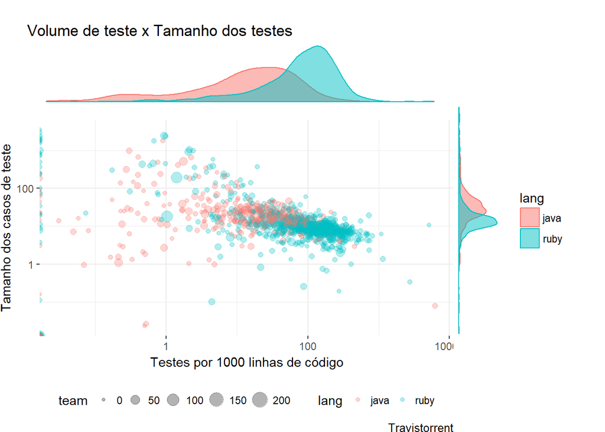

```r
set.seed(42)
theme_set(theme_bw())  # pre-set the bw theme.
DF <- data.frame(x=rnorm(100,mean=c(1,5)),y=rlnorm(100,meanlog=c(8,6)),group=1:2)

p1 <- projetos %>% ggplot(aes(x= tests_per_kloc, y= test_size_avg, size=team, color=lang)) +
  geom_point(alpha = .3) +
  #scale_x_continuous(expand=c(0.02,0)) +
  #scale_y_continuous(expand=c(0.02,0)) +
    scale_x_log10()+
    scale_y_log10()+
        labs(x='Testes por 1000 linhas de código',
             y='Tamanho dos casos de teste',
             title=NULL,
             subtitle=NULL,
             caption="Travistorrent") +
  theme_bw() +
  theme(panel.border=element_blank(),
        legend.position="bottom",
        plot.margin=unit(c(10,0,0,0),"points"))



p2 <- projetos %>% ggplot(aes(x=tests_per_kloc,colour=lang,fill=lang)) +
  geom_density(alpha=0.5) +
  #scale_x_continuous(breaks=NULL,expand=c(0.02,0)) +
  #scale_y_continuous(breaks=NULL,expand=c(0.02,0)) +
  scale_x_log10()+
        labs(x=NULL,
             y=NULL) +
        labs(title="Volume de teste x Tamanho dos testes") +
  theme_bw() +
  theme(plot.background=element_rect(fill="#ffffff"),
        legend.background = element_rect(fill="#ffffff"),
        panel.background=element_rect(fill="#ffffff"),
        panel.grid.minor=element_blank(),
        panel.grid.major.y=element_blank(),
        panel.grid.major.x=element_blank(),
        axis.ticks=element_blank(),
        axis.text.x = element_blank(),
        axis.text.y = element_blank(),
        panel.border=element_blank(),
        legend.position="none",
        plot.margin=unit(c(20,0,0,20),"points"))

p3 <- projetos %>% ggplot(aes(x=test_size_avg,colour=lang,fill=lang)) +
  geom_density(alpha=0.5) +
  #scale_x_continuous(labels = NULL,breaks=NULL,expand=c(0.02,0)) +
  #scale_y_continuous(labels = NULL,breaks=NULL,expand=c(0.02,0)) +
  scale_x_log10()+
  coord_flip()  +
  labs(x=NULL,
             y=NULL) +
  theme(plot.background=element_rect(fill="#ffffff"),
        legend.background = element_rect(fill="#ffffff"),
        panel.background=element_rect(fill="#ffffff"),
        panel.grid.minor=element_blank(),
        panel.grid.major.y=element_blank(),
        panel.grid.major.x=element_blank(),
        axis.ticks=element_blank(),
        axis.text.x = element_blank(),
        axis.text.y = element_blank(),
        panel.border=element_blank(),
        legend.position="right",
        plot.margin=unit(c(-10,30,70,0),"points"))

grid.arrange(arrangeGrob(p2,ncol=2,widths=c(3,1)),
             arrangeGrob(p1,p3,ncol=2,widths=c(3,1)),
             heights=c(1,3))
```

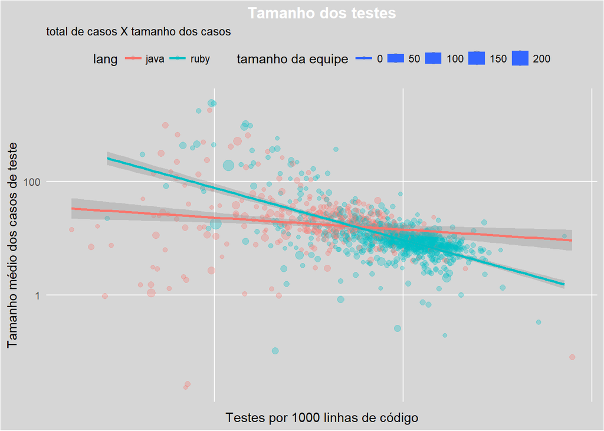

```r
theme_set(theme_bw())  # pre-set the bw theme.
projetos %>%
    ggplot(aes(x= tests_per_kloc, y= test_size_avg, size=team, color=lang),na.rm=TRUE) +
    scale_x_log10()+
    scale_y_log10()+
    geom_count(alpha = .3) +

    stat_smooth(method='lm',na.rm=TRUE)+



    labs(subtitle="total de casos X tamanho dos casos",
       y="Tamanho médio dos casos de teste",
       x="Testes por 1000 linhas de código",
       title="Tamanho dos testes",
       size="tamanho da equipe") +
        theme(plot.title = element_text(hjust=0.5, face="bold", color="#ffffff"),
              plot.background=element_rect(fill="#d6d6d6"),
              panel.background=element_rect(fill="#d6d6d6"),
              legend.background = element_rect(fill="#d6d6d6"),
              panel.grid.minor=element_blank(),
              panel.grid.major.y=element_line(color="#ffffff"),
              panel.grid.major.x=element_line(color="#ffffff"),
              axis.ticks=element_blank(),
              legend.position="top",
              axis.text.x = element_blank(),
              panel.border=element_blank())
```

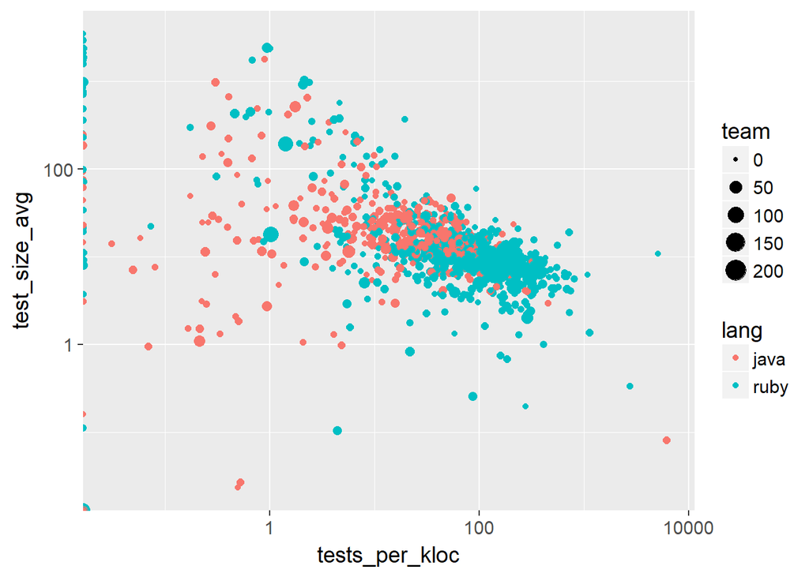

```r
#theme_set(theme_bw())  # pre-set the bw theme.
#g <- projetos %>%
#        ggplot(aes(x= tests_per_kloc, y= test_size_avg, size = team, frame = lang)) +
#        geom_point() +
#        geom_smooth(aes(group = lang),
#              method = "lm",
#              show.legend = FALSE) +
#        facet_wrap(~continent, scales = "free") +
#        scale_x_log10()  # convert to log scale

#gganimate(g, interval=0.2)







# The mtcars dataset is proposed in R
#head(mtcars)

theme_set(theme_bw())  # pre-set the bw theme.

# classic plot :
projetos %>%
    ggplot(aes(x= tests_per_kloc, y= test_size_avg, color=lang, size=team)) +
      geom_point() +
        scale_y_log10()+
        scale_x_log10()+
      #theme(legend.position="none")+
    theme_gray(base_size = 14)
```

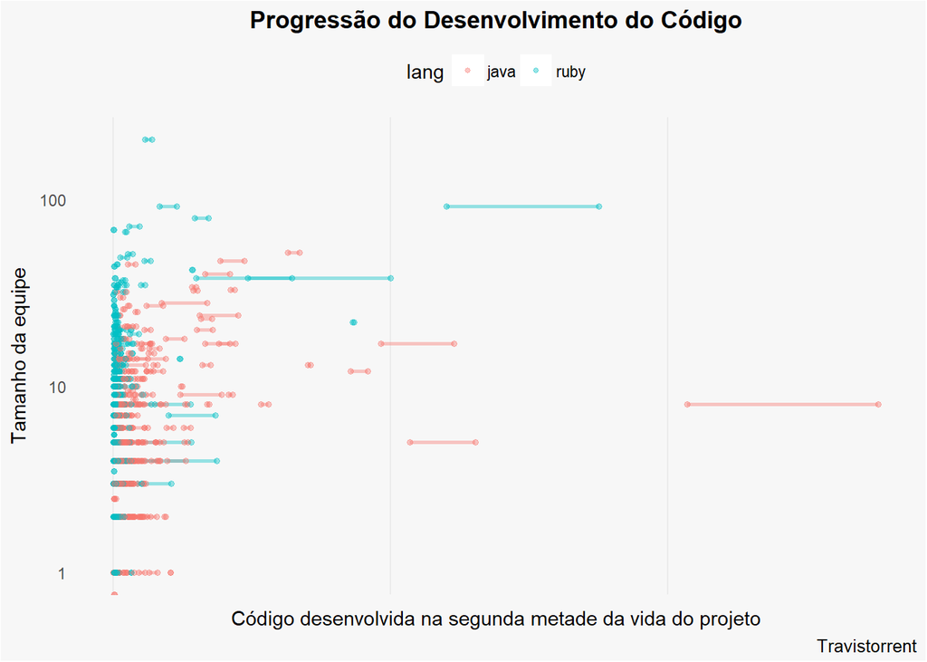

```r
# with marginal histogram
#ggMarginal(p, type="histogram")

# marginal density
#ggMarginal(p, type="density")

# marginal boxplot
#ggMarginal(ppp, type="boxplot")



gg <- projetos %>%
    ggplot(aes(x=sloc_med, xend=sloc_end, y=team, group=team, color=lang)) +
        geom_dumbbell(
                      #color="#a3c4dc",
                      size=1.0,
                      alpha=.4,
                      #colour_xend = "#0e668b"
                      ) +
        #scale_x_continuous(label=percent) +

        scale_y_log10()+
        labs(x='Código desenvolvida na segunda metade da vida do projeto',
             y='Tamanho da equipe',
             title="Progressão do Desenvolvimento do Código",
             subtitle=NULL,
             caption="Travistorrent") +
        theme(plot.title = element_text(hjust=0.5, face="bold"),
              plot.background=element_rect(fill="#f7f7f7"),
              panel.background=element_rect(fill="#f7f7f7"),
              legend.background = element_rect(fill="#f7f7f7"),
              panel.grid.minor=element_blank(),
              panel.grid.major.y=element_blank(),
              panel.grid.major.x=element_line(),
              axis.ticks=element_blank(),
              legend.position="top",
              axis.text.x = element_blank(),
              panel.border=element_blank())
plot(gg)
```

[figure not shown]

```r
theme_set(theme_bw())  # pre-set the bw theme.
projetos %>%
    filter(team <= 10) %>%
    group_by(team) %>%
    summarise(mean_team =mean(team), sd_team=sd(team)) %>%
    mutate(team2=as.character(team),team_total = round((team - mean_team)/sd_team, 2)) %>%
    ggplot(aes(x= team2, y= team_total), label='um label') +
    geom_bar(stat='identity', aes(fill=ifelse(team_total < 0, "below", "above")), width=.5)  +
    scale_fill_manual(name="Mileage",
                    labels = c("Above Average", "Below Average"),
                    values = c("above"="#00ba38", "below"="#f8766d")) +
    labs(subtitle="Normalised mileage from 'mtcars'",
       title= "Diverging Bars") +
    coord_flip()
```

[figure not shown]

```r
theme_set(theme_bw())  # pre-set the bw theme.
projetos %>%
    mutate(team = round((team - mean(team))/sd(team), 2)) %>%
    ggplot(stat='identity', aes(x= lang, y= team))  +
    scale_fill_manual(name="Mileage",
                    labels = c("Above Average", "Below Average"),
                    values = c("above"="#00ba38", "below"="#f8766d")) +
    labs(subtitle="Normalised mileage from 'mtcars'",
       title= "Diverging Bars") +
    coord_flip()
```

[figure not shown]

```r
m<-projetos %>%
    group_by(team) %>%
    summarise(n=n())
media<-m %>%
    summarise(n=mean(n))
dp<-m %>%
    summarise(n=sd(n))

theme_set(theme_bw())  # pre-set the bw theme.
projetos %>%
    group_by(team) %>%
    summarise(n=n()) %>%
    ggplot(aes(x= team, y= round((n-media)/dp))) +
    geom_col(fill = "darkcyan", color = "darkcyan")
```

### 1.[Pergunta 3] Qual linguagem produz mais código?

Se esta pergunta for feita à um programador familiarizado com ambas as linguagens, provavelmente ele terá a sua resposta. Porém, a mesma pergunta sendo feita à um outro possivelmente será respondida de forma diferente. Para chegarmos a uma conclusão a partir dos dados devemos calcular a **produtividade** média dos nossos programadores. Esta variável é obtida a partir do total de linhas de código dividido pela equipe multiplicada pelo tempo de duração do projeto.

O objetivo é estimar quanto código cada programador pode produzir num dado tempo. Linguagens mais “prolixas” levam programadores à produzir mais código. Como este valor representa um valor médio, de tendência central, habilidades específicas ou grau de experiência não são avaliadas aqui.

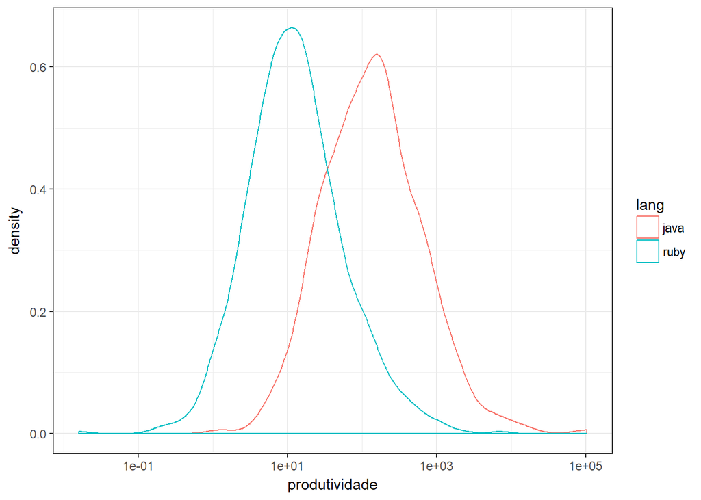

```r
projetos %>%
    mutate(produtividade = sloc_end / (team * activity_period)) %>%
    ggplot(aes(x= produtividade, color = lang)) +
    scale_x_log10() +
    geom_density()
```

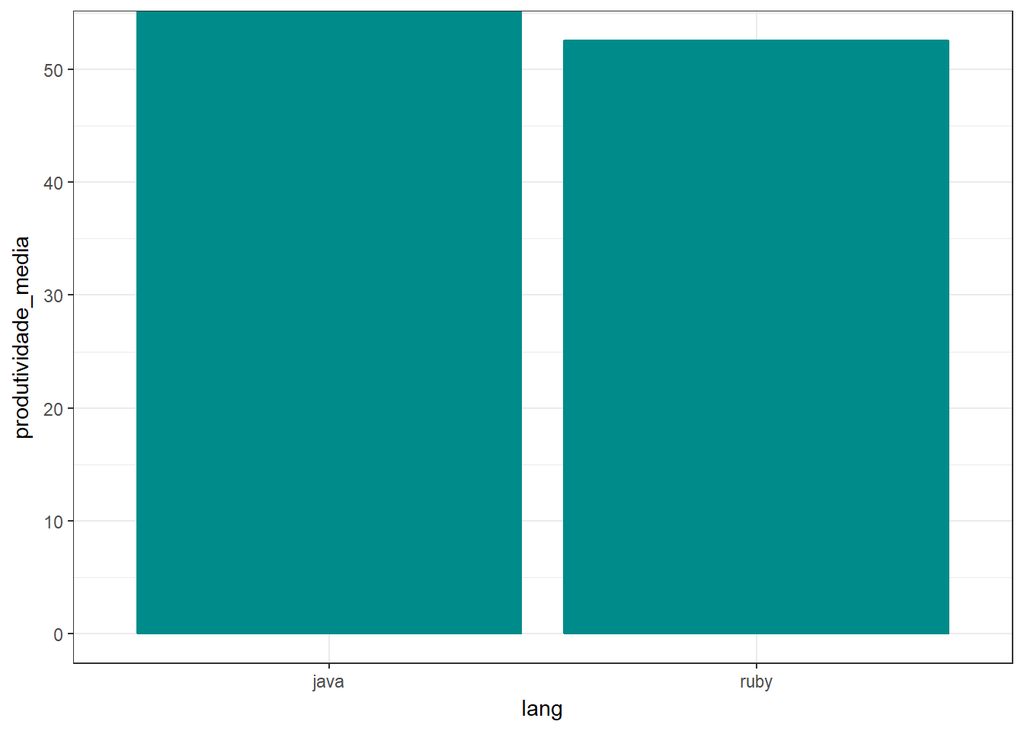

```r
projetos %>%
    mutate(produtividade = sloc_end / (team * activity_period)) %>%
    group_by(lang) %>%
    summarise(produtividade_media = mean(produtividade)) %>%
    ggplot(aes(x = lang, y= produtividade_media)) +
    geom_col(fill = "darkcyan", color = "darkcyan")
```

```r
projetos %>%
    group_by(lang) %>%
    summarise(total_desenvolvedores_por_linguagem = sum(team))
```

| lang | total_desenvolvedores_por_linguagem |
| --- | --- |
| java | 2736.5 |
| ruby | 6473.0 |

### 1.1. Com base nos dados podemos afirmar que produzir mais código leva a linguagem a casos de testes maiores?

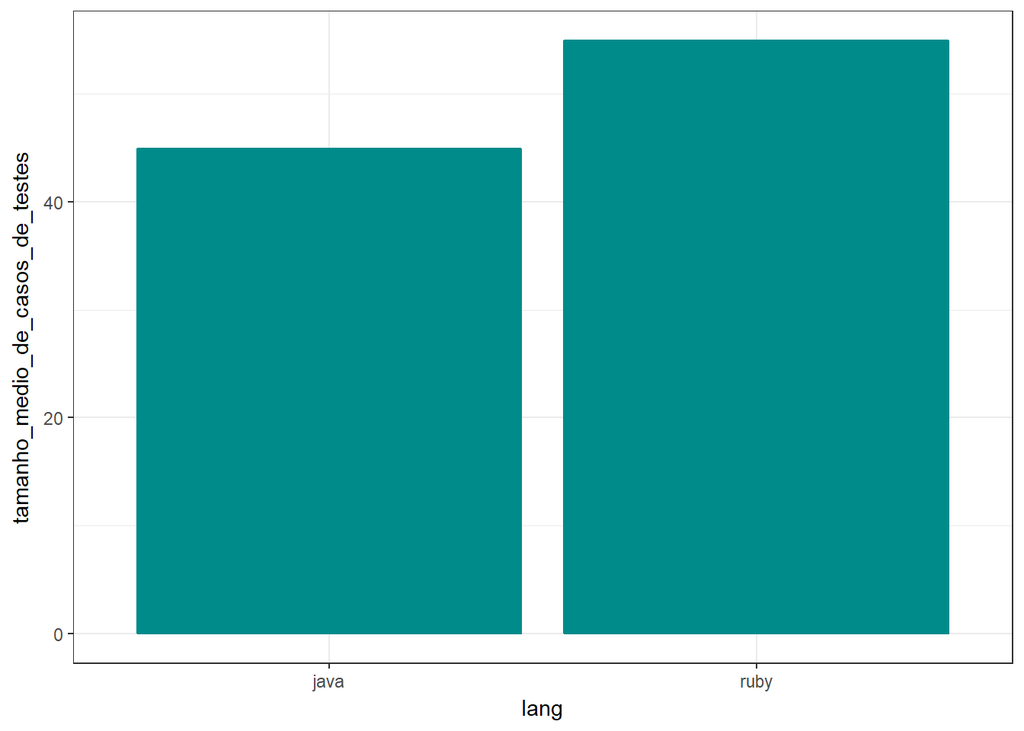

```r
projetos %>%
    group_by(lang) %>%
    summarise(tamanho_medio_de_casos_de_testes = mean(test_size_avg)) %>%
    ggplot(aes(x = lang, y= tamanho_medio_de_casos_de_testes )) +
    geom_col(fill = "darkcyan", color = "darkcyan")
```

### 2.[Pergunta 6] Testes maiores implicam em menos testes?

Observando o gráfico abaixo, que descreve o tamanho médio de linhas de código de um caso de teste (y) pelo total de casos de teste por mil linhas de código (x), uma resposta clara que podemos dar é: Casos de testes médios muito grandes (mais de 100 linhas) só ocorrem em projetos com poucos testes, além de alguns projetos com apenas um ou dois casos de teste de milhares de linhas de código. Além desta constatação e observando a forma e direção da distribuição dos dados, vemos que há uma tendência geral, sobretudo para Ruby, que relaciona inversamente estas duas variáveis. Note que, para facilitar a visualização, o gráfico abaixo está em escala logarítmica. A relação entre estas variáveis é bem mais íngreme em escala linear, porém de difícil visualização.

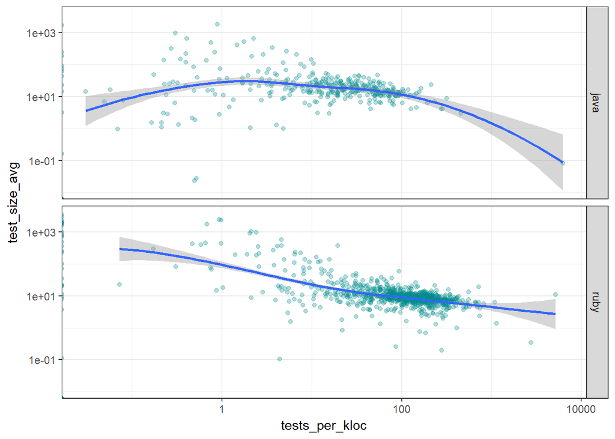

```r
projetos %>%
    ggplot(aes(x= tests_per_kloc, y= test_size_avg)) +
    scale_x_log10()+
    scale_y_log10()+
    geom_point(alpha = .3, color = "darkcyan") +
    stat_smooth(method = "loess")+
    facet_grid(lang ~ .)
```

### 2.2. Menos testes implicam em menos sucesso nos *builds*?

Levando a questão anterior em termos práticos, se o projeto implementa testes com frequência (geralmente pequenos ou médios) isto o leva a mais sucesso nos *builds*? No gráfico abaixo, onde comparamos o total de casos de teste por mil linhas de código com a proporção de sucesso não conseguimos ver muita relação entre estas duas variáveis.

A partir deste gráfico dá para concluir que, por mais que haja um acumulo de projeto com um certo volume de testes (esta tendência varia entre as linguagens), a variável “sucesso nos *builds*” (**build_success_prop**) não apresenta uma forma ou direção clara em sua distribuição.

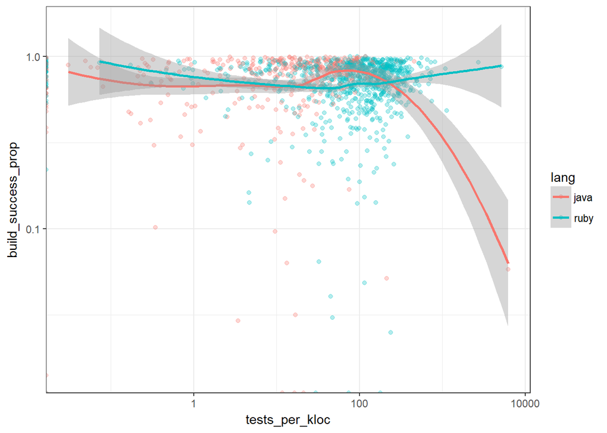

```r
projetos %>%
    ggplot(aes(x= tests_per_kloc, y= build_success_prop , color = lang),na.rm=TRUE) +
    scale_x_log10()+
    scale_y_log10()+
    geom_point(alpha = .3) +
    stat_smooth(method='loess',na.rm=TRUE)
```